# Differential expression analysis for 2025-06 release JAX_RNAseq09

Bo Yu, Si Liu, Wei Sun

2025-08-14

Differential expression using the bulk RNAseq JAX_RNAseq09 data from the June 2025 release.

See bulk_RNAseq.xlsx for details of the dataset.

## R libraries.

```r
library(ggplot2)
library(ggrepel)
library(ggpubr)
library(stringr)
library(MASS)
library(RColorBrewer)
library(DESeq2)
library(viridis)
library(ggpointdensity)
library(tidyverse)
library(data.table)
library(ComplexHeatmap)
library(UpSetR)
library(readxl)
library(ggsci)
library(ggprism)
theme_set(theme_classic())

path = "../../MorPhiC/data/MorPhiC_internal_releases/MorPhiC_Release_June_2025/JAX_RNAseq09/"
dat_path = file.path(path, "processed/Tables")
```

## Read in meta data

```r
meta = fread("data/June_2025/JAX_RNAseq09_meta_data.tsv", data.table = FALSE)
dim(meta)
```

```
## [1] 39 36
```

```r
meta[1:2, ]
```

```
##   clonal.label library_preparation.label            label
## 1 MOK20069-WT1                GT24-08511 CBO-MOK20069-WT1
## 2 MOK20069-WT2                GT24-08512 CBO-MOK20069-WT2
##                                          description
## 1 KOLF2.2J differentiated to cortical brain organoid
## 2 KOLF2.2J differentiated to cortical brain organoid
##                 differentiated_product_protocol_id model_system timepoint_value
## 1 dx.doi.org/10.17504/protocols.io.kxygxw1ddv8j/v1          CBO              14
## 2 dx.doi.org/10.17504/protocols.io.kxygxw1ddv8j/v1          CBO              14
##   timepoint_unit final_timepoint treatment_condition wt_control_status
## 1           days             yes      Not applicable                WT
## 2           days             yes      Not applicable                WT
##   ko_strategy ko_gene library_preparation.description
## 1          WT      WT                              NA
## 2          WT      WT                              NA
##   library_preparation.library_preparation_protocol_id
## 1    dx.doi.org/10.17504/protocols.io.3byl4z39ovo5/v1
## 2    dx.doi.org/10.17504/protocols.io.3byl4z39ovo5/v1
##   library_preparation.average_fragment_size
## 1                                       423
## 2                                       422
##   library_preparation.input_amount_value library_preparation.input_amount_unit
## 1                                    300                                    ng
## 2                                    300                                    ng
##   library_preparation.concentration_value
## 1                                    6.44
## 2                                    6.04
##   library_preparation.concentration_unit library_preparation.total_yield_value
## 1                                  ng/uL                                 128.8
## 2                                  ng/uL                                 120.8
##   library_preparation.total_yield_unit library_preparation.cdna_pcr_cycles
## 1                                   ng                                   0
## 2                                   ng                                   0
##   library_preparation.pcr_cycles_for_indexing
## 1                                          10
## 2                                          10
##                                           file_id                   run_id
## 1 WT1_Day14_GT24-08511_TCCAACGC-AAGTCCAA_S70_L007 20240909_GT24-RobsonP-19
## 2 WT2_Day14_GT24-08512_CCGTGAAG-ATCCACTG_S67_L007 20240909_GT24-RobsonP-19
##   clonal.description clonal.parental_name clonal.clone_id clonal.type
## 1           KOLF2.2J             KOLF2.2J             WT1        iPSC
## 2           KOLF2.2J             KOLF2.2J             WT2        iPSC
##   clonal.zygosity clonal.cell_line_generation_protocol
## 1  Not applicable                       Not applicable
## 2  Not applicable                       Not applicable
##   clonal.treatment_condition clonal.wt_control_status
## 1             Not applicable                       WT
## 2             Not applicable                       WT
##   expression_alteration.label                                  model_organ
## 1              Not applicable Cortical brain (dorsal forebrain patterning)
## 2              Not applicable Cortical brain (dorsal forebrain patterning)
```

```r
names(meta)
```

```
##  [1] "clonal.label"
##  [2] "library_preparation.label"
##  [3] "label"
##  [4] "description"
##  [5] "differentiated_product_protocol_id"
##  [6] "model_system"
##  [7] "timepoint_value"
##  [8] "timepoint_unit"
##  [9] "final_timepoint"
## [10] "treatment_condition"
## [11] "wt_control_status"
## [12] "ko_strategy"
## [13] "ko_gene"
## [14] "library_preparation.description"
## [15] "library_preparation.library_preparation_protocol_id"
```

[output cut: 21 more lines]

```r
names(meta)[apply(meta, 2, \(x) any(is.na(x)))]
```

```
## [1] "library_preparation.description"
```

```r
table(meta$clonal.label)
```

```
##
##       MOK20069-WT1       MOK20069-WT2       MOK20069-WT4      MOK20069P-A08
##                  1                  1                  1                  1
##      MOK20069P-E08      MOK20069P-F09       MOK20070-WT1       MOK20070-WT2
##                  1                  1                  1                  1
##       MOK20070-WT4      MOK20070P-C11      MOK20070P-D11      MOK20070P-G12
##                  1                  1                  1                  1
## MOK20075_78_86-WT2 MOK20075_78_86-WT3 MOK20075_78_86-WT4      MOK20075P-A06
##                  1                  1                  1                  1
##      MOK20075P-A11      MOK20075P-B01      MOK20078P-A10      MOK20078P-C10
##                  1                  1                  1                  1
##      MOK20078P-E12      MOK20086P-A11      MOK20086P-C11      MOK20086P-C12
##                  1                  1                  1                  1
##      MOK20088P-A02      MOK20088P-B03      MOK20088P-E02    MOK20090_88-WT2
##                  1                  1                  1                  1
##    MOK20090_88-WT3    MOK20090_88-WT4      MOK20090P-A07      MOK20090P-B10
##                  1                  1                  1                  1
##      MOK20090P-D07       MOK20092-WT1       MOK20092-WT2       MOK20092-WT4
##                  1                  1                  1                  1
##      MOK20092P-F03      MOK20092P-G02      MOK20092P-G04
##                  1                  1                  1
```

```r
table(table(meta$clonal.label))
```

```
##
##  1
## 39
```

```r
table(table(meta$label))
```

```
##
##  1
## 39
```

```r
meta$timepoint = as.factor(meta$timepoint_value)
```

### Add gene group information

```r
unique(meta$clonal.description)
```

```
## [1] "KOLF2.2J"
## [2] "KOLF2.2J EMX2 null by insertion of a premature termination codon with frameshift (PTC+1)"
## [3] "KOLF2.2J FOXG1 null by insertion of a premature termination codon with frameshift (PTC+1)"
## [4] "KOLF2.2J POU3F2 null by insertion of a premature termination codon with frameshift (PTC+1)"
## [5] "KOLF2.2J SOX1 null by insertion of a premature termination codon with frameshift (PTC+1)"
## [6] "KOLF2.2J HES5 null by insertion of a premature termination codon with frameshift (PTC+1)"
## [7] "KOLF2.2J POU3F1 null by insertion of a premature termination codon with frameshift (PTC+1)"
## [8] "KOLF2.2J SOX21 null by insertion of a premature termination codon with frameshift (PTC+1)"
## [9] "KOLF2.2J SP8 null by insertion of a premature termination codon with frameshift (PTC+1)"
```

```r
# Add clonal.description for WT clones, to specify which KO samples they serve as controls for
table(meta$clonal.label, meta$ko_gene)
```

```
##
##                      EMX2 FOXG1 HES5 POU3F1 POU3F2 SOX1 SOX21 SP8 WT
##   MOK20069-WT1          0     0    0      0      0    0     0   0  1
##   MOK20069-WT2          0     0    0      0      0    0     0   0  1
##   MOK20069-WT4          0     0    0      0      0    0     0   0  1
##   MOK20069P-A08         1     0    0      0      0    0     0   0  0
##   MOK20069P-E08         1     0    0      0      0    0     0   0  0
##   MOK20069P-F09         1     0    0      0      0    0     0   0  0
##   MOK20070-WT1          0     0    0      0      0    0     0   0  1
##   MOK20070-WT2          0     0    0      0      0    0     0   0  1
##   MOK20070-WT4          0     0    0      0      0    0     0   0  1
##   MOK20070P-C11         0     1    0      0      0    0     0   0  0
##   MOK20070P-D11         0     1    0      0      0    0     0   0  0
##   MOK20070P-G12         0     1    0      0      0    0     0   0  0
##   MOK20075_78_86-WT2    0     0    0      0      0    0     0   0  1
##   MOK20075_78_86-WT3    0     0    0      0      0    0     0   0  1
##   MOK20075_78_86-WT4    0     0    0      0      0    0     0   0  1
##   MOK20075P-A06         0     0    0      0      1    0     0   0  0
##   MOK20075P-A11         0     0    0      0      1    0     0   0  0
##   MOK20075P-B01         0     0    0      0      1    0     0   0  0
##   MOK20078P-A10         0     0    0      0      0    1     0   0  0
##   MOK20078P-C10         0     0    0      0      0    1     0   0  0
##   MOK20078P-E12         0     0    0      0      0    1     0   0  0
##   MOK20086P-A11         0     0    1      0      0    0     0   0  0
##   MOK20086P-C11         0     0    1      0      0    0     0   0  0
##   MOK20086P-C12         0     0    1      0      0    0     0   0  0
##   MOK20088P-A02         0     0    0      1      0    0     0   0  0
##   MOK20088P-B03         0     0    0      1      0    0     0   0  0
##   MOK20088P-E02         0     0    0      1      0    0     0   0  0
##   MOK20090_88-WT2       0     0    0      0      0    0     0   0  1
##   MOK20090_88-WT3       0     0    0      0      0    0     0   0  1
##   MOK20090_88-WT4       0     0    0      0      0    0     0   0  1
##   MOK20090P-A07         0     0    0      0      0    0     1   0  0
##   MOK20090P-B10         0     0    0      0      0    0     1   0  0
##   MOK20090P-D07         0     0    0      0      0    0     1   0  0
##   MOK20092-WT1          0     0    0      0      0    0     0   0  1
##   MOK20092-WT2          0     0    0      0      0    0     0   0  1
##   MOK20092-WT4          0     0    0      0      0    0     0   0  1
##   MOK20092P-F03         0     0    0      0      0    0     0   1  0
##   MOK20092P-G02         0     0    0      0      0    0     0   1  0
##   MOK20092P-G04         0     0    0      0      0    0     0   1  0
```

```r
meta[meta$ko_gene == 'WT', 'clonal.description'] = sapply(meta[meta$ko_gene == 'WT', 'clonal.label'], \(wt_clone_label) {
  ko_clone_labels = sub("-WT\\d+$", "", wt_clone_label)
  ko_clone_labels = strsplit(ko_clone_labels, split = '_', fixed = TRUE)[[1]]
  if (length(ko_clone_labels) > 1) {
    ko_clone_labels = c(
      ko_clone_labels[1],
      paste0("MOK20", sprintf("%03d", as.integer(ko_clone_labels[-1])))
    )
  }
  rx = paste0("^(", paste(ko_clone_labels, collapse = "|"), ")")
  ko_genes = sort(unique(meta$ko_gene[grepl(rx, meta$clonal.label) & meta$ko_gene != "WT"]))
  stopifnot(all(!is.na(ko_genes)), length(ko_genes) > 0)
  paste0("KOLF2.2J control for ", paste(ko_genes, collapse = ", "))
})
meta[meta$ko_gene == 'WT', c('clonal.label', 'clonal.description')]
```

```
##          clonal.label                      clonal.description
## 1        MOK20069-WT1               KOLF2.2J control for EMX2
## 2        MOK20069-WT2               KOLF2.2J control for EMX2
## 3        MOK20069-WT4               KOLF2.2J control for EMX2
## 7        MOK20070-WT1              KOLF2.2J control for FOXG1
## 8        MOK20070-WT2              KOLF2.2J control for FOXG1
## 9        MOK20070-WT4              KOLF2.2J control for FOXG1
## 13 MOK20075_78_86-WT2 KOLF2.2J control for HES5, POU3F2, SOX1
## 14 MOK20075_78_86-WT3 KOLF2.2J control for HES5, POU3F2, SOX1
## 15 MOK20075_78_86-WT4 KOLF2.2J control for HES5, POU3F2, SOX1
## 28    MOK20090_88-WT2      KOLF2.2J control for POU3F1, SOX21
## 29    MOK20090_88-WT3      KOLF2.2J control for POU3F1, SOX21
## 30    MOK20090_88-WT4      KOLF2.2J control for POU3F1, SOX21
## 34       MOK20092-WT1                KOLF2.2J control for SP8
## 35       MOK20092-WT2                KOLF2.2J control for SP8
## 36       MOK20092-WT4                KOLF2.2J control for SP8
```

```r
# Add gene group as one factor to specify which samples go to same DE analysis
# One gene only goes to one gene_group in this dataset
# List all gene groups
gene_group = table(meta[meta$ko_gene == 'WT', 'clonal.description']) |>
  unclass() |>
  as.data.frame() |>
  (\(x) {
    names(x) = 'nor'
    x
  })() |>
  rownames_to_column(var = 'desc') |>
  mutate(
    gene_group = sapply(strsplit(desc, 'for '), \(x) paste0(strsplit(x[2], ', ')[[1]], collapse = '_')),
    gene_list = strsplit(gene_group, '_')
  )
gene_group
```

```
##                                      desc nor       gene_group    gene_list
## 1               KOLF2.2J control for EMX2   3             EMX2         EMX2
## 2              KOLF2.2J control for FOXG1   3            FOXG1        FOXG1
## 3 KOLF2.2J control for HES5, POU3F2, SOX1   3 HES5_POU3F2_SOX1 HES5, PO....
## 4      KOLF2.2J control for POU3F1, SOX21   3     POU3F1_SOX21 POU3F1, ....
## 5                KOLF2.2J control for SP8   3              SP8          SP8
```

```r
# Create gene_group column for meta data
meta$gene_group = unlist(plyr::alply(meta, 1, \(x) {
  group = if (x$ko_gene != 'WT') {
    gene_group |>
      filter(sapply(gene_list, \(genes) x$ko_gene %in% genes)) |>
      pull(gene_group)
  } else {
    gene_group |>
      filter(desc == x$clonal.description) |>
      pull(gene_group)
  }
  stopifnot(length(group) == 1)
  group
}))
table(meta$ko_gene, meta$gene_group)
```

```
##
##          EMX2 FOXG1 HES5_POU3F2_SOX1 POU3F1_SOX21 SP8
##   EMX2      3     0                0            0   0
##   FOXG1     0     3                0            0   0
##   HES5      0     0                3            0   0
##   POU3F1    0     0                0            3   0
##   POU3F2    0     0                3            0   0
##   SOX1      0     0                3            0   0
##   SOX21     0     0                0            3   0
##   SP8       0     0                0            0   3
##   WT        3     3                3            3   3
```

```r
table(meta$ko_gene, meta$gene_group, meta$timepoint, meta$model_system)
```

```
## , ,  = 8,  = CBO
##
##
##          EMX2 FOXG1 HES5_POU3F2_SOX1 POU3F1_SOX21 SP8
##   EMX2      0     0                0            0   0
##   FOXG1     0     3                0            0   0
##   HES5      0     0                0            0   0
##   POU3F1    0     0                0            3   0
##   POU3F2    0     0                0            0   0
##   SOX1      0     0                0            0   0
##   SOX21     0     0                0            3   0
##   SP8       0     0                0            0   0
##   WT        0     3                0            3   0
##
## , ,  = 9,  = CBO
##
##
##          EMX2 FOXG1 HES5_POU3F2_SOX1 POU3F1_SOX21 SP8
##   EMX2      0     0                0            0   0
##   FOXG1     0     0                0            0   0
##   HES5      0     0                0            0   0
##   POU3F1    0     0                0            0   0
##   POU3F2    0     0                0            0   0
##   SOX1      0     0                0            0   0
##   SOX21     0     0                0            0   0
##   SP8       0     0                0            0   3
##   WT        0     0                0            0   3
##
## , ,  = 11,  = CBO
##
##
##          EMX2 FOXG1 HES5_POU3F2_SOX1 POU3F1_SOX21 SP8
##   EMX2      0     0                0            0   0
##   FOXG1     0     0                0            0   0
##   HES5      0     0                3            0   0
##   POU3F1    0     0                0            0   0
##   POU3F2    0     0                3            0   0
##   SOX1      0     0                3            0   0
##   SOX21     0     0                0            0   0
##   SP8       0     0                0            0   0
##   WT        0     0                3            0   0
##
## , ,  = 14,  = CBO
##
##
##          EMX2 FOXG1 HES5_POU3F2_SOX1 POU3F1_SOX21 SP8
##   EMX2      3     0                0            0   0
##   FOXG1     0     0                0            0   0
##   HES5      0     0                0            0   0
##   POU3F1    0     0                0            0   0
##   POU3F2    0     0                0            0   0
##   SOX1      0     0                0            0   0
##   SOX21     0     0                0            0   0
##   SP8       0     0                0            0   0
##   WT        3     0                0            0   0
```

## Read in gene count data

```r
cts = fread(file.path(dat_path, "genesCounts.csv"), data.table = FALSE)
dim(cts)
```

```
## [1] 36601    40
```

```r
cts[1:2, c(1:2, (ncol(cts) - 1) : ncol(cts))]
```

```
##              Name SP8_WT_2_GT24-12109_ATATGGAT-TAATACAG_S73_L008
## 1 ENSG00000268674                                              0
## 2 ENSG00000271254                                           1168
##   POU3F2_PTC_A11_Day11_GT24-08523_CGGACAAC-AATCCGGA_S53_L007
## 1                                                          2
## 2                                                       2892
##   SOX1_PTC_A10_Day11_GT24-08525_GCGCAAGC-CGGCGTGA_S66_L007
## 1                                                        0
## 2                                                     1288
```

```r
# Align counts with meta data
stopifnot(
  setequal(meta$file_id, names(cts)[-1]),
  !any(duplicated(meta$file_id)),
  !any(duplicated(names(cts)[-1]))
)
meta = meta[match(names(cts)[-1], meta$file_id), ]
# To matrix
cts_dat = data.matrix(cts[, -1])
rownames(cts_dat) = cts$Name
```

### Exclude genes without annotation

```r
# Read in gene annotation
gene_anno = fread("data/gencode_v44_primary_assembly_info.tsv")
dim(gene_anno)
```

```
## [1] 62754     8
```

```r
gene_anno[1:2, ]
```

```
##                geneId  chr strand     start       end ensembl_gene_id
## 1: ENSG00000000003.16 chrX      - 100627108 100639991 ENSG00000000003
## 2:  ENSG00000000005.6 chrX      + 100584936 100599885 ENSG00000000005
##    hgnc_symbol                                       description
## 1:      TSPAN6 tetraspanin 6 [Source:HGNC Symbol;Acc:HGNC:11858]
## 2:        TNMD   tenomodulin [Source:HGNC Symbol;Acc:HGNC:17757]
```

```r
# Make sure all KO genes have unique ensembl gene id
gene_anno |>
  filter(hgnc_symbol %in% setdiff(meta$ko_gene, 'WT')) |>
  arrange(hgnc_symbol)
```

```
##                geneId   chr strand     start       end ensembl_gene_id
## 1: ENSG00000170370.12 chr10      + 117542445 117549546 ENSG00000170370
## 2: ENSG00000176165.13 chr14      +  28764329  28770277 ENSG00000176165
## 3:  ENSG00000197921.6  chr1      -   2528745   2530263 ENSG00000197921
## 4:  ENSG00000185668.8  chr1      -  38043829  38046793 ENSG00000185668
## 5: ENSG00000184486.10  chr6      +  98834574  98839458 ENSG00000184486
## 6:  ENSG00000182968.5 chr13      + 112067149 112071706 ENSG00000182968
## 7:  ENSG00000125285.6 chr13      -  94709622  94712545 ENSG00000125285
## 8: ENSG00000164651.18  chr7      -  20782279  20786886 ENSG00000164651
##    hgnc_symbol
## 1:        EMX2
## 2:       FOXG1
## 3:        HES5
## 4:      POU3F1
## 5:      POU3F2
## 6:        SOX1
## 7:       SOX21
## 8:         SP8
##                                                                   description
## 1:              empty spiracles homeobox 2 [Source:HGNC Symbol;Acc:HGNC:3341]
## 2:                         forkhead box G1 [Source:HGNC Symbol;Acc:HGNC:3811]
## 3: hes family bHLH transcription factor 5 [Source:HGNC Symbol;Acc:HGNC:19764]
## 4:                  POU class 3 homeobox 1 [Source:HGNC Symbol;Acc:HGNC:9214]
## 5:                  POU class 3 homeobox 2 [Source:HGNC Symbol;Acc:HGNC:9215]
## 6:         SRY-box transcription factor 1 [Source:HGNC Symbol;Acc:HGNC:11189]
## 7:        SRY-box transcription factor 21 [Source:HGNC Symbol;Acc:HGNC:11197]
## 8:               Sp8 transcription factor [Source:HGNC Symbol;Acc:HGNC:19196]
```

```r
# Exclude genes without annotation
table(rownames(cts_dat) %in% gene_anno$ensembl_gene_id)
```

```
##
## FALSE  TRUE
##   211 36390
```

```r
cts = cts[cts$Name %in% gene_anno$ensembl_gene_id, ]
cts_dat = cts_dat[rownames(cts_dat) %in% gene_anno$ensembl_gene_id, ]
```

### Discard genes whose expression is 0 in more than 75% of samples

```r
gene_info = data.frame(
  apply(cts_dat, 1, tapply, meta$model_system, min),
  apply(cts_dat, 1, tapply, meta$model_system, median),
  apply(cts_dat, 1, tapply, meta$model_system, \(x) quantile(x, probs = 0.75)),
  apply(cts_dat, 1, tapply, meta$model_system, max)
)
gene_info[1:2, ]
```

```
##                 apply.cts_dat..1..tapply..meta.model_system..min.
## ENSG00000268674                                                 0
## ENSG00000271254                                               711
##                 apply.cts_dat..1..tapply..meta.model_system..median.
## ENSG00000268674                                                    0
## ENSG00000271254                                                 1271
##                 apply.cts_dat..1..tapply..meta.model_system..function.x..quantile.x..
## ENSG00000268674                                                                     0
## ENSG00000271254                                                                  1907
##                 apply.cts_dat..1..tapply..meta.model_system..max.
## ENSG00000268674                                                 2
## ENSG00000271254                                              2892
```

```r
names(gene_info) = paste0(
  rep(c("CBO_"), times = 4),
  rep(c("min", "median", "q75", "max"), each = 1)
)
summary(gene_info)
```

```
##     CBO_min           CBO_median          CBO_q75            CBO_max
##  Min.   :     0.0   Min.   :     0.0   Min.   :     0.0   Min.   :      0.0
##  1st Qu.:     0.0   1st Qu.:     0.0   1st Qu.:     0.0   1st Qu.:      1.0
##  Median :     0.0   Median :     2.0   Median :     4.0   Median :      9.5
##  Mean   :   456.3   Mean   :   686.6   Mean   :   794.8   Mean   :   1048.5
##  3rd Qu.:   203.8   3rd Qu.:   345.0   3rd Qu.:   416.0   3rd Qu.:    589.0
##  Max.   :296199.0   Max.   :670574.0   Max.   :876624.5   Max.   :1482140.0
```

```r
table(gene_info$CBO_q75 > 0)
```

```
##
## FALSE  TRUE
## 13894 22496
```

```r
# Subset genes
w2kp = which(gene_info$CBO_q75 > 0)
cts_dat = cts_dat[w2kp, ]
gene_info = gene_info[w2kp, ]
```

### Check read depth vs. gene expression quantile

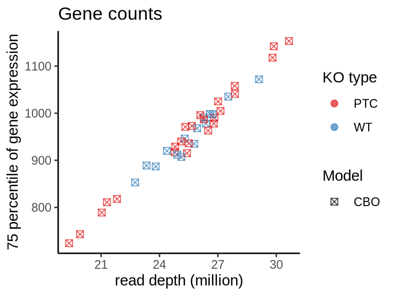

```r
meta$read_depth = colSums(cts_dat)/1e6
meta$q75 = apply(cts_dat, 2, quantile, probs = 0.75)

ggplot(meta, aes(x=read_depth, y=q75, color=ko_strategy, shape = model_system)) +
    geom_point(size=2, alpha=0.7) + ggtitle("Gene counts") +
  scale_shape_manual(values = c(7, 16)) +
  xlab("read depth (million)") + ylab("75 percentile of gene expression") +
  labs(color = "KO type", shape = "Model") +
  scale_color_brewer(palette = "Set1")
```

```r
unique(meta$run_id)
```

```
## [1] "20241202_GT24-RobsonP-94" "20240909_GT24-RobsonP-19"
```

```r
meta$run_id_short = meta$run_id
table(meta$model_system, meta$run_id_short)
```

```
##
##       20240909_GT24-RobsonP-19 20241202_GT24-RobsonP-94
##   CBO                       24                       15
```

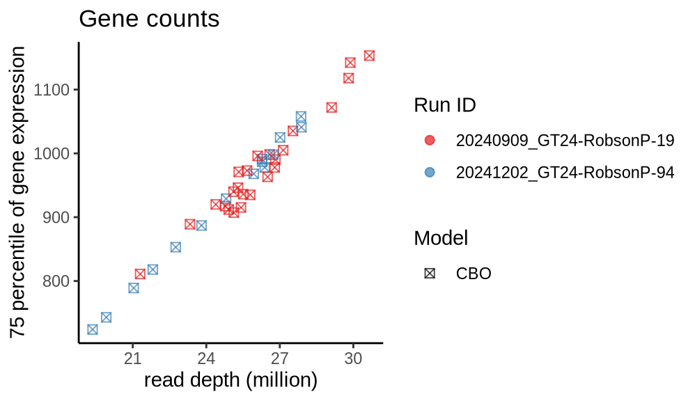

```r
ggplot(meta, aes(x=read_depth, y=q75, color=run_id_short, shape = model_system)) +
    geom_point(size=2, alpha=0.7) + ggtitle("Gene counts") +
  scale_shape_manual(values = c(7, 16)) +
  xlab("read depth (million)") + ylab("75 percentile of gene expression") +
  labs(color = "Run ID", shape = "Model") +
  scale_color_brewer(palette = "Set1")
```

## Check PCA result of WT samples

```r
sample2kp = which(meta$ko_gene == "WT")
cts_dat_m = cts_dat[,sample2kp]
meta_m    = meta[sample2kp,]
summary(meta_m$q75)
```

```
##    Min. 1st Qu.  Median    Mean 3rd Qu.    Max.
##   853.0   909.6   946.2   952.7   994.5  1072.0
```

```r
dim(cts_dat_m)
```

```
## [1] 22496    15
```

```r
stopifnot(all(meta_m$file_id == colnames(cts_dat_m)))
table(meta_m$file_id == colnames(cts_dat_m), useNA="ifany")
```

```
##
## TRUE
##   15
```

```r
q75 = apply(cts_dat_m, 1, quantile, probs=0.75)
cts_dat_n = t(cts_dat_m[q75 > 0,])
cts_dat_n = log(median(meta_m$q75)*cts_dat_n/meta_m$q75 + 1)
dim(cts_dat_n)
```

```
## [1]    15 22259
```

```r
sample_pca = prcomp(cts_dat_n, center = TRUE, scale. = TRUE)
names(sample_pca)
```

```
## [1] "sdev"     "rotation" "center"   "scale"    "x"
```

```r
pc_scores = sample_pca$x
eigen_vals = sample_pca$sdev^2
eigen_vals[1:5]/sum(eigen_vals)
```

```
## [1] 0.36393019 0.17342900 0.10975494 0.05840911 0.04825896
```

```r
pvs = round(eigen_vals[1:5]/sum(eigen_vals)*100,1)
pvs
```

```
## [1] 36.4 17.3 11.0  5.8  4.8
```

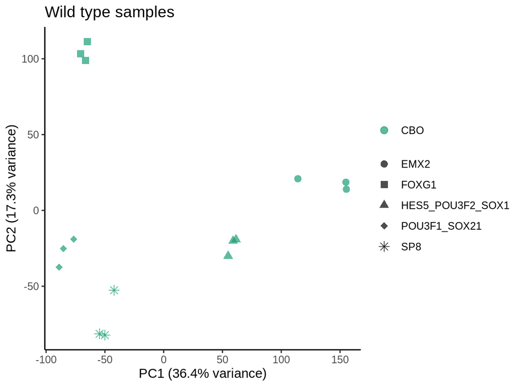

```r
PC_df = data.frame(pc_scores)
PC_df = cbind(PC_df, meta_m)

gPC = ggplot(PC_df, aes(x = PC1, y = PC2, shape=gene_group, color=model_system)) +
  geom_point(size=2.5, alpha=0.7) + scale_color_brewer(palette = "Dark2") +
  scale_shape_prism() +
  labs(color="Model system", shape ="Gene group") +
  xlab(sprintf("PC1 (%.1f%% variance)", pvs[1])) +
  ylab(sprintf("PC2 (%.1f%% variance)", pvs[2])) +
  ggtitle("Wild type samples") +
  guides(
    color = guide_legend(title = NULL, order = 1),
    shape = guide_legend(title = NULL, order = 2)
  ) +
  theme(
    legend.margin = margin(0, 0, 0, 0),
    legend.box.just = "left",
    legend.direction = "vertical"
  )

print(gPC)
```

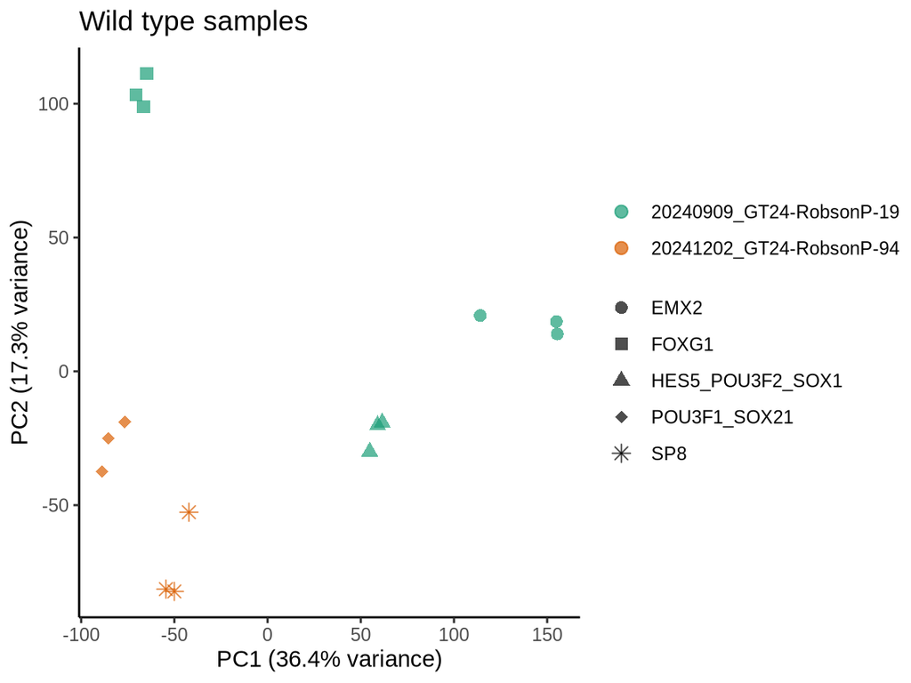

```r
gPC = ggplot(PC_df, aes(x = PC1, y = PC2, shape=gene_group,
                        color=run_id_short)) +
  geom_point(size=2.5, alpha=0.7) +
  scale_color_brewer(palette = "Dark2") +
  scale_shape_prism() +
  labs(color="Run_id", shape ="Gene group") +
  xlab(sprintf("PC1 (%.1f%% variance)", pvs[1])) +
  ylab(sprintf("PC2 (%.1f%% variance)", pvs[2])) +
  ggtitle("Wild type samples") +
  guides(
    color = guide_legend(title = NULL, order = 1),
    shape = guide_legend(title = NULL, order = 2)
  ) +
  theme(
    legend.margin = margin(0, 0, 0, 0),
    legend.box.just = "left",
    legend.direction = "vertical"
  )

print(gPC)
```

## Analyze samples of different model systems or batches

```r
meta$condition = 'nor'
meta$model_condition = paste(meta$model_system, meta$condition, sep="_")
table(meta$model_condition)
```

```
##
## CBO_nor
##      39
```

```r
table(meta$run_id, meta$model_condition)
```

```
##
##                            CBO_nor
##   20240909_GT24-RobsonP-19      24
##   20241202_GT24-RobsonP-94      15
```

```r
table(meta$run_id, meta$ko_gene)
```

```
##
##                            EMX2 FOXG1 HES5 POU3F1 POU3F2 SOX1 SOX21 SP8 WT
##   20240909_GT24-RobsonP-19    3     3    3      0      3    3     0   0  9
##   20241202_GT24-RobsonP-94    0     0    0      3      0    0     3   3  6
```

```r
table(meta$run_id, meta$gene_group)
```

```
##
##                            EMX2 FOXG1 HES5_POU3F2_SOX1 POU3F1_SOX21 SP8
##   20240909_GT24-RobsonP-19    6     6               12            0   0
##   20241202_GT24-RobsonP-94    0     0                0            9   6
```

```r
table(meta$ko_strategy, meta$ko_gene)
```

```
##
##       EMX2 FOXG1 HES5 POU3F1 POU3F2 SOX1 SOX21 SP8 WT
##   PTC    3     3    3      3      3    3     3   3  0
##   WT     0     0    0      0      0    0     0   0 15
```

```
## [1] ""
## [1] "=========================================="
## [1] "CBO_nor"
## [1] "=========================================="
## [1] ""
##
##  1
## 39
##
##       PTC WT
##   PTC  24  0
##   WT    0 15
##
##                    EMX2 FOXG1 HES5 POU3F1 POU3F2 SOX1 SOX21 SP8 WT
##   EMX2                3     0    0      0      0    0     0   0  3
##   FOXG1               0     3    0      0      0    0     0   0  3
##   HES5_POU3F2_SOX1    0     0    3      0      3    3     0   0  3
##   POU3F1_SOX21        0     0    0      3      0    0     3   0  3
##   SP8                 0     0    0      0      0    0     0   3  3
```

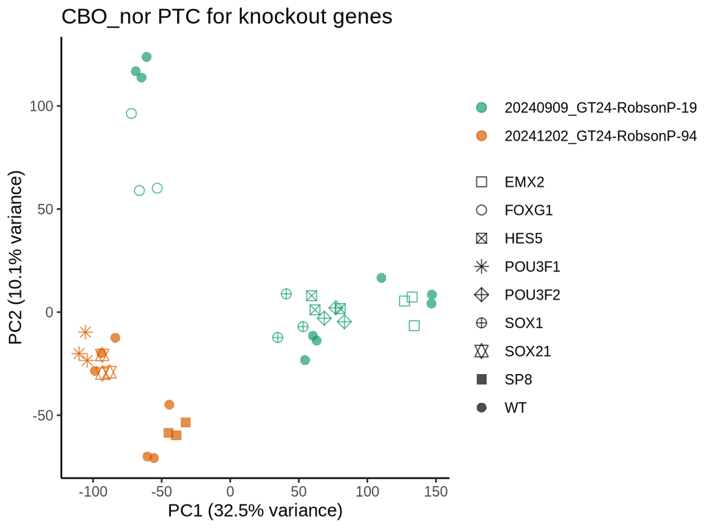

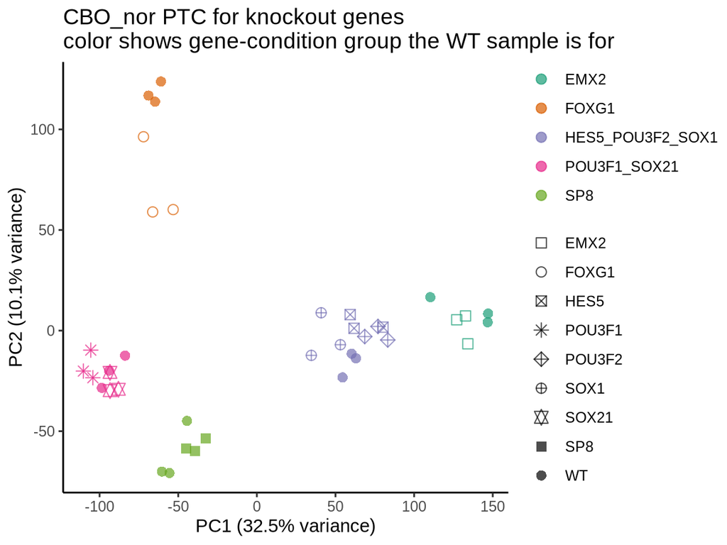

```r
unique_model_condition_ss = unique(meta$model_condition)
unique_model_condition_ss = sort(unique_model_condition_ss)

for(cur_mc in unique_model_condition_ss){
  print("")
  print("==========================================")
  print(cur_mc)
  print("==========================================")
  print("")

  sample2kp = which(meta$model_condition == cur_mc)
  cts_dat_m = cts_dat[,sample2kp]
  meta_m    = meta[sample2kp,]

  # verify the consistency between ko_strategy from metadata column and
  # that from filenames
  extracted_ko_strings = str_extract_all(meta_m$file_id, "PTC|WT")
  print(table(sapply(extracted_ko_strings, length)))
  print(table(meta_m$ko_strategy, unlist(extracted_ko_strings)))

  stopifnot(all(meta_m$file_id == colnames(cts_dat_m)))
  table(meta_m$file_id == colnames(cts_dat_m), useNA="ifany")


  q75 = apply(cts_dat_m, 1, quantile, probs=0.75)

  cts_dat_n = t(cts_dat_m[q75 > 0,])
  cts_dat_n = log(median(meta_m$q75)*cts_dat_n/meta_m$q75 + 1)
  dim(cts_dat_n)

  sample_pca = prcomp(cts_dat_n, center = TRUE, scale. = TRUE)
  names(sample_pca)
  pc_scores = sample_pca$x
  eigen_vals = sample_pca$sdev^2
  eigen_vals[1:5]/sum(eigen_vals)
  pvs = round(eigen_vals[1:5]/sum(eigen_vals)*100,1)
  pvs

  PC_df = data.frame(pc_scores)
  PC_df = cbind(PC_df, meta_m)

  colnames(PC_df)[which(colnames(PC_df)=="timepoint")] = "day"

  only_ko_strategy = setdiff(unique(PC_df$ko_strategy), "WT")

  unique_ko_genes = sort(unique(PC_df$ko_gene))
  unique_ko_genes = c(unique_ko_genes[unique_ko_genes!="WT"], "WT")
  PC_df$ko_gene = factor(PC_df$ko_gene, unique_ko_genes)

  print(table(PC_df$gene_group, PC_df$ko_gene, useNA="ifany"))

  shapes = c(0, 1, 7, 8, 9, 10, 11, 15, 16, 17)


  table(meta_m$clonal.description, meta_m$timepoint)

  gPC = ggplot(PC_df, aes(x = PC1, y = PC2, shape=ko_gene, color=run_id_short)) +
              geom_point(size=2.5, alpha=0.7) +
              scale_color_brewer(palette = "Dark2") +
              scale_shape_manual(values = shapes[1:length(unique(PC_df$ko_gene))]) +
              xlab(sprintf("PC1 (%.1f%% variance)", pvs[1])) +
              ylab(sprintf("PC2 (%.1f%% variance)", pvs[2])) +
              ggtitle(paste0(cur_mc, " ", only_ko_strategy, " for knockout genes")) +
              guides(
                color = guide_legend(title = NULL, order = 1),
                shape = guide_legend(title = NULL, order = 2)
              ) +
              theme(
                legend.margin = margin(0, 0, 0, 0),
                legend.box.just = "left",
                legend.direction = "vertical"
              )

  print(gPC)

  gPC = ggplot(PC_df, aes(x = PC1, y = PC2, shape=ko_gene, color=gene_group)) +
              geom_point(size=2.5, alpha=0.7) + scale_color_brewer(palette = "Dark2") +
                scale_shape_manual(values = shapes[1:length(unique(PC_df$ko_gene))]) +
              xlab(sprintf("PC1 (%.1f%% variance)", pvs[1])) +
              ylab(sprintf("PC2 (%.1f%% variance)", pvs[2])) +
              ggtitle(paste0(cur_mc, " ", only_ko_strategy, " for knockout genes\n",
                             "color shows gene-condition group the WT sample is for")) +
              guides(
                color = guide_legend(title = NULL, order = 1),
                shape = guide_legend(title = NULL, order = 2)
              ) +
              theme_classic() +
              theme(
                legend.margin = margin(0, 0, 0, 0),
                legend.box.just = "left",
                legend.direction = "vertical"
              )

  print(gPC)

}
```

Run DE analysis for each gene group separately. They natually separate all batches.

```r
table(meta$gene_group, meta$run_id, meta$timepoint, meta$model_system)
```

```
## , ,  = 8,  = CBO
##
##
##                    20240909_GT24-RobsonP-19 20241202_GT24-RobsonP-94
##   EMX2                                    0                        0
##   FOXG1                                   6                        0
##   HES5_POU3F2_SOX1                        0                        0
##   POU3F1_SOX21                            0                        9
##   SP8                                     0                        0
##
## , ,  = 9,  = CBO
##
##
##                    20240909_GT24-RobsonP-19 20241202_GT24-RobsonP-94
##   EMX2                                    0                        0
##   FOXG1                                   0                        0
##   HES5_POU3F2_SOX1                        0                        0
##   POU3F1_SOX21                            0                        0
##   SP8                                     0                        6
##
## , ,  = 11,  = CBO
##
##
##                    20240909_GT24-RobsonP-19 20241202_GT24-RobsonP-94
##   EMX2                                    0                        0
##   FOXG1                                   0                        0
##   HES5_POU3F2_SOX1                       12                        0
##   POU3F1_SOX21                            0                        0
##   SP8                                     0                        0
##
## , ,  = 14,  = CBO
##
##
##                    20240909_GT24-RobsonP-19 20241202_GT24-RobsonP-94
##   EMX2                                    6                        0
##   FOXG1                                   0                        0
##   HES5_POU3F2_SOX1                        0                        0
##   POU3F1_SOX21                            0                        0
##   SP8                                     0                        0
```

For the output files, create two versions, one with direct information, one with padj set to NA for the genes when the number of 0 per test is >=4.

In more details, for both versions of the outputs, make it one file per knockout gene per DE group (DE group can be model system, model system + condition, model system + run_id, model system + day, etc.).

The first version of the output files contains

```
gene id, gene symbol
```

and for each knockout strategy:

```
baseMean, log2FoldChange, lfcSE, stat, pvalue, padj
```

The second version of the output files contains

```
gene id, gene symbol, chr, strand, position
```

and for each knockout strategy:

```
log2FoldChange, pvalue, padj (set to be NA if the number of 0 per test >= 4).
```

In addition, save out a separate file of the sample size for each comparison. This needs to be by DE group.

### Prepare output directories for DE results

```r
release_name = "2025_06_JAX_RNAseq09"

output_dir = file.path("results", release_name)
raw_output_dir = file.path(output_dir, "raw")
processed_output_dir = file.path(output_dir, "processed")

if (!file.exists(raw_output_dir)){
  dir.create(raw_output_dir, recursive = TRUE)
}

if (!file.exists(processed_output_dir)){
  dir.create(processed_output_dir, recursive = TRUE)
}
```

### DE analysis for all genes

```
## [1] ""
## [1] "=========================================="
## [1] "CBO"
## [1] "=========================================="
## [1] ""
##
##                            EMX2 FOXG1 HES5 POU3F1 POU3F2 SOX1 SOX21 SP8 WT
##   20240909_GT24-RobsonP-19    3     3    3      0      3    3     0   0  9
##   20241202_GT24-RobsonP-94    0     0    0      3      0    0     3   3  6
##
##          8 9 11 14
##   EMX2   0 0  0  3
##   FOXG1  3 0  0  0
##   HES5   0 0  3  0
##   POU3F1 3 0  0  0
##   POU3F2 0 0  3  0
##   SOX1   0 0  3  0
##   SOX21  3 0  0  0
##   SP8    0 3  0  0
##   WT     6 3  3  3
##
##                           8 9 11 14
##   EMX2_EMX2               0 0  0  3
##   FOXG1_FOXG1             3 0  0  0
##   HES5_HES5_POU3F2_SOX1   0 0  3  0
##   POU3F1_POU3F1_SOX21     3 0  0  0
##   POU3F2_HES5_POU3F2_SOX1 0 0  3  0
##   SOX1_HES5_POU3F2_SOX1   0 0  3  0
##   SOX21_POU3F1_SOX21      3 0  0  0
##   SP8_SP8                 0 3  0  0
##   WT_EMX2                 0 0  0  3
##   WT_FOXG1                3 0  0  0
##   WT_HES5_POU3F2_SOX1     0 0  3  0
##   WT_POU3F1_SOX21         3 0  0  0
##   WT_SP8                  0 3  0  0
## [1] "---------------------------"
## [1] "Model system: CBO"
## [1] "On day_condition 11_nor: "
## [1] "Cross table between knockout gene and run id:"
##
```

[output cut: 48 more lines]

```
##   SP8                        3
##   WT                         3
## [1] "Cross table between knockout gene and knockout gene group:"
##
##       SP8
##   SP8   3
##   WT    3
## [1] ""
## [1] "-----------------------------------"
## [1] "Model system: CBO"
## [1] "DE group CBO_day_11_HES5_POU3F2_SOX1 DESeq2 results:"
## [1] "-----------------------------------"
## [1] "After filtering by gene expression q75, the number of genes reduces from 22496 to 21736"
## [1] "After filtering by nonzero expression in at least 4 samples, the number of genes reduces from 21736 to 21247"
## Time difference of 1.080565 mins
```

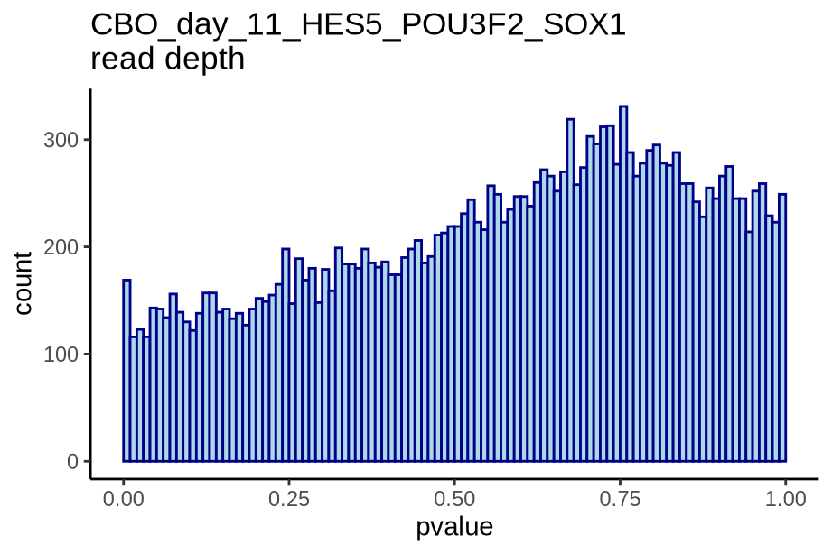

```
## [1] "prop of non-null for rd: 0.00e+00"
## [1] "rerun DESeq2 without read depth"
## [1] "CBO_day_11_HES5_POU3F2_SOX1 under KO gene HES5:"
## [1] "number of DE genes: 55"
```

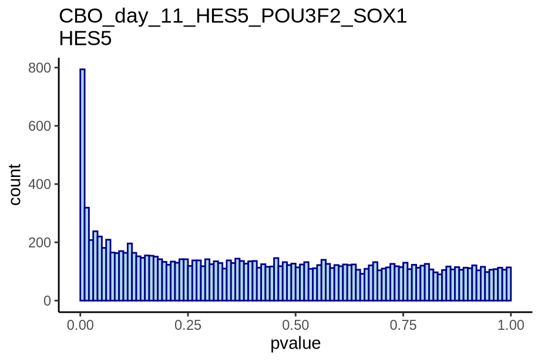

```
## [1] "hgnc_symbol empty string and NA tables:"
##
## FALSE  <NA>
## 17898  3349
##
## FALSE  TRUE
## 17898  3349
## [1] "CBO_day_11_HES5_POU3F2_SOX1 under KO gene POU3F2:"
## [1] "number of DE genes: 76"
```

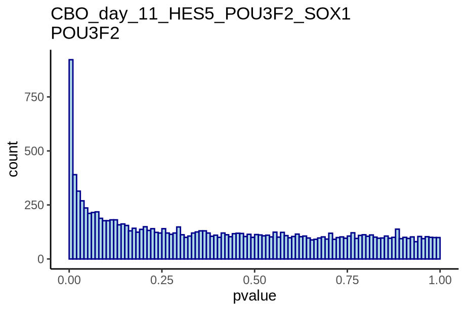

```
## [1] "hgnc_symbol empty string and NA tables:"
##
## FALSE  <NA>
## 17898  3349
##
## FALSE  TRUE
## 17898  3349
## [1] "CBO_day_11_HES5_POU3F2_SOX1 under KO gene SOX1:"
## [1] "number of DE genes: 322"
```

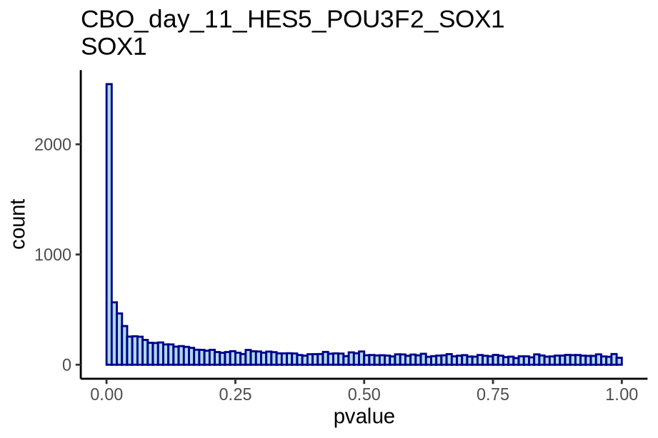

```
## [1] "hgnc_symbol empty string and NA tables:"
##
## FALSE  <NA>
## 17898  3349
##
## FALSE  TRUE
## 17898  3349
## [1] ""
## [1] "-----------------------------------"
## [1] "Model system: CBO"
## [1] "DE group CBO_day_14_EMX2 DESeq2 results:"
## [1] "-----------------------------------"
## [1] "After filtering by gene expression q75, the number of genes reduces from 22496 to 21192"
## [1] "After filtering by nonzero expression in at least 4 samples, the number of genes reduces from 21192 to 19471"
## Time difference of 39.00937 secs
```

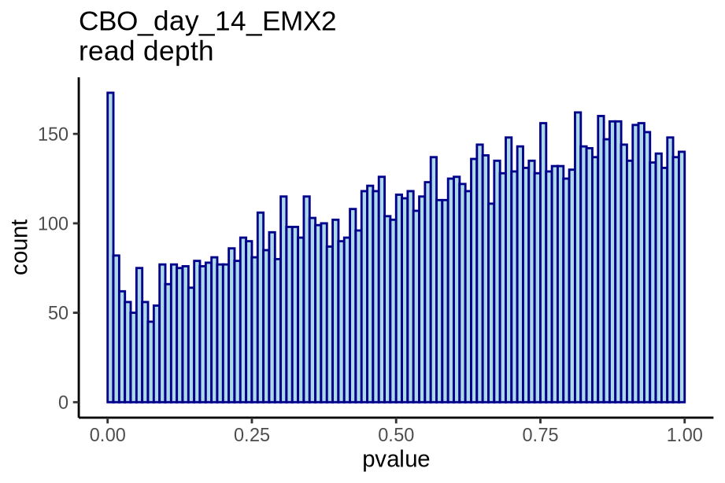

```
## [1] "prop of non-null for rd: 0.00e+00"
## [1] "rerun DESeq2 without read depth"
## [1] "CBO_day_14_EMX2 under KO gene EMX2:"
## [1] "number of DE genes: 65"
```

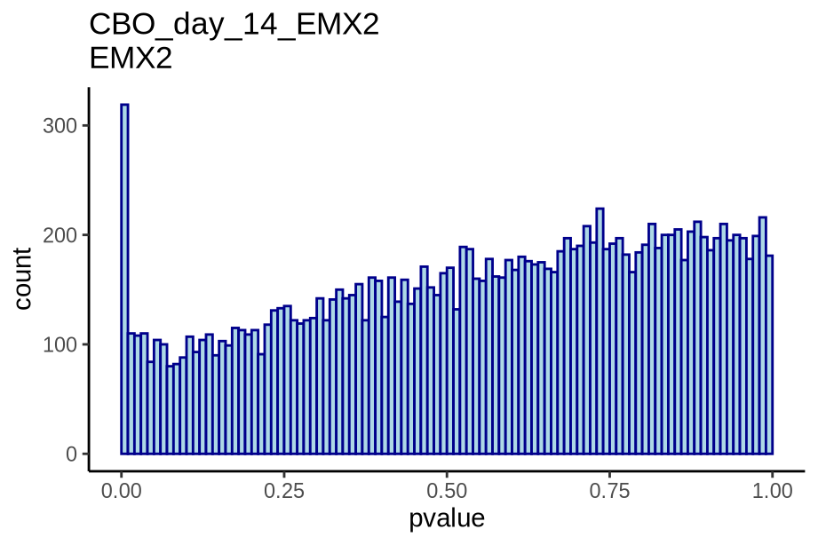

```
## [1] "hgnc_symbol empty string and NA tables:"
##
## FALSE  <NA>
## 16954  2517
##
## FALSE  TRUE
## 16954  2517
## [1] ""
## [1] "-----------------------------------"
## [1] "Model system: CBO"
## [1] "DE group CBO_day_8_FOXG1 DESeq2 results:"
## [1] "-----------------------------------"
## [1] "After filtering by gene expression q75, the number of genes reduces from 22496 to 21209"
## [1] "After filtering by nonzero expression in at least 4 samples, the number of genes reduces from 21209 to 19411"
## Time difference of 43.6726 secs
```

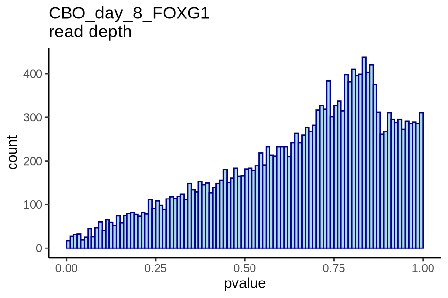

```
## [1] "prop of non-null for rd: 0.00e+00"
## [1] "rerun DESeq2 without read depth"
## [1] "CBO_day_8_FOXG1 under KO gene FOXG1:"
## [1] "number of DE genes: 103"
```

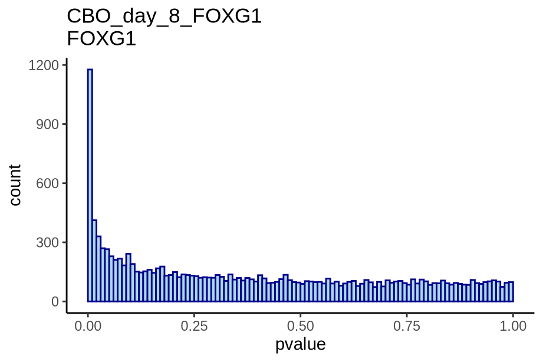

```
## [1] "hgnc_symbol empty string and NA tables:"
##
## FALSE  <NA>
## 16990  2421
##
## FALSE  TRUE
## 16990  2421
## [1] ""
## [1] "-----------------------------------"
## [1] "Model system: CBO"
## [1] "DE group CBO_day_8_POU3F1_SOX21 DESeq2 results:"
## [1] "-----------------------------------"
## [1] "After filtering by gene expression q75, the number of genes reduces from 22496 to 22028"
## [1] "After filtering by nonzero expression in at least 4 samples, the number of genes reduces from 22028 to 21569"
## Time difference of 22.82111 secs
```

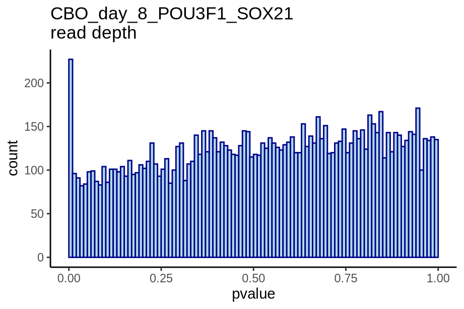

```
## [1] "prop of non-null for rd: 0.00e+00"
## [1] "rerun DESeq2 without read depth"
## [1] "CBO_day_8_POU3F1_SOX21 under KO gene POU3F1:"
## [1] "number of DE genes: 300"
```

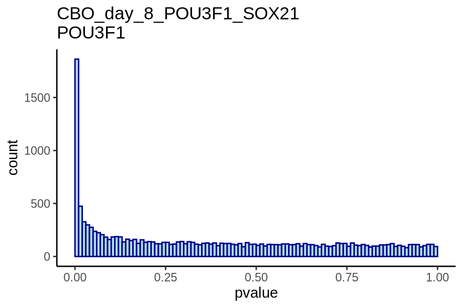

```
## [1] "hgnc_symbol empty string and NA tables:"
##
## FALSE  <NA>
## 18123  3446
##
## FALSE  TRUE
## 18123  3446
## [1] "CBO_day_8_POU3F1_SOX21 under KO gene SOX21:"
## [1] "number of DE genes: 210"
```

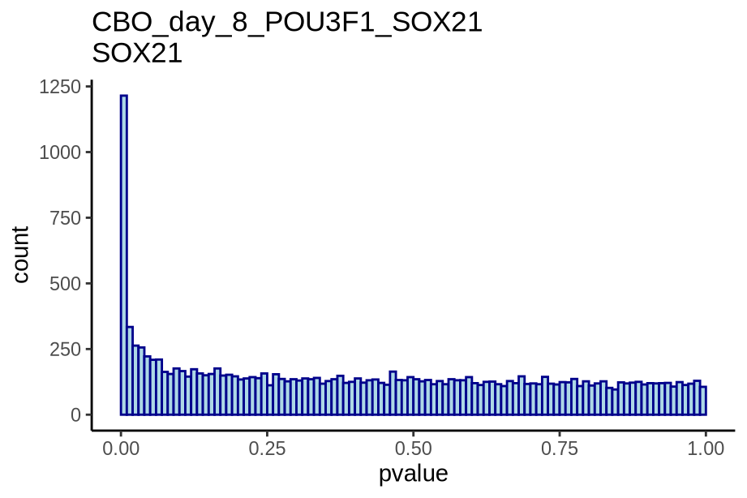

```
## [1] "hgnc_symbol empty string and NA tables:"
##
## FALSE  <NA>
## 18123  3446
##
## FALSE  TRUE
## 18123  3446
## [1] ""
## [1] "-----------------------------------"
## [1] "Model system: CBO"
## [1] "DE group CBO_day_9_SP8 DESeq2 results:"
## [1] "-----------------------------------"
## [1] "After filtering by gene expression q75, the number of genes reduces from 22496 to 21943"
## [1] "After filtering by nonzero expression in at least 4 samples, the number of genes reduces from 21943 to 20407"
## Time difference of 16.47037 secs
```

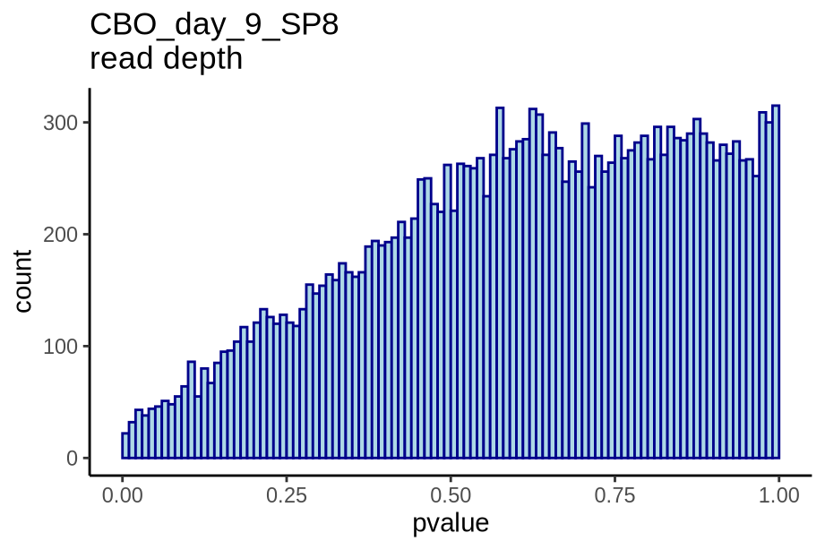

```
## [1] "prop of non-null for rd: 0.00e+00"
## [1] "rerun DESeq2 without read depth"
## [1] "CBO_day_9_SP8 under KO gene SP8:"
## [1] "number of DE genes: 401"
```

[1 more figures not shown]

```
## [1] "hgnc_symbol empty string and NA tables:"
##
## FALSE  <NA>
## 17418  2989
##
## FALSE  TRUE
## 17418  2989
```

```r
df_size = NULL

unique_model_ss = unique(meta$model_system)
unique_model_ss = sort(unique_model_ss)

for(model1 in unique_model_ss){

  print("")
  print("==========================================")
  print(model1)
  print("==========================================")
  print("")

  sample2kp = which(meta$model_system == model1)

  cts_dat_m = cts_dat[,sample2kp]
  meta_m    = meta[sample2kp,]

  table(meta_m$ko_strategy)
  stopifnot(all(meta_m$file_id == colnames(cts_dat_m)))

  ## Generate sample information matrix
  cols2kp = c("model_system", "condition", "ko_strategy", "ko_gene", "gene_group",
              "run_id", "run_id_short", "timepoint", "q75")
  sample_info = meta_m[,cols2kp]
  colnames(sample_info)[which(colnames(sample_info)=="timepoint")] = "day"

  dim(sample_info)
  sample_info[1:2,]

  sample_info$ko_gene_gene_group = paste(sample_info$ko_gene,
                                         sample_info$gene_group, sep="_")

  print(table(sample_info$run_id, sample_info$ko_gene))
  print(table(sample_info$ko_gene, sample_info$day))
  print(table(sample_info$ko_gene_gene_group, sample_info$day))

  # print the table of ko_gene and run_id by (day, condition) combinations
  sample_info$day_condition = paste0(sample_info$day, "_", sample_info$condition)
  unique_day_condition_model_s = unique(sample_info$day_condition)
  unique_day_condition_model_s = as.character(sort(unique_day_condition_model_s))

  for (cur_d_c in as.character(unique_day_condition_model_s)){
    sample_info_by_day = sample_info[which(sample_info$day_condition==as.character(cur_d_c)), ]
    print("---------------------------")
    print(paste0("Model system: ", model1))
    print(paste0("On day_condition ", as.character(cur_d_c), ": "))
    print("Cross table between knockout gene and run id:")
    print(table(sample_info_by_day$ko_gene, sample_info_by_day$run_id_short))
    print("Cross table between knockout gene and knockout gene group:")
    print(table(sample_info_by_day$ko_gene, sample_info_by_day$gene_group))
  }

  sample_info$model_day = paste0(sample_info$model_system,
                                 "_day_",
                                 as.character(sample_info$day))

  sample_info$de_grp = sample_info$model_day

  sample_info$de_grp = paste0(sample_info$de_grp, "_", sample_info$gene_group)

  unique_de_grps = unique(sample_info$de_grp)
  sorted_de_grps = sort(unique_de_grps)

  for (d_group in sorted_de_grps){

    dg_index = which(sample_info$de_grp==d_group)
    cts_dat_m_dg = cts_dat_m[, dg_index]
    sample_info_dg = sample_info[dg_index, ]

    stopifnot(all(sample_info_dg$de_grp==d_group))

    print("")
    print("-----------------------------------")
    print(paste0("Model system: ", model1))
    if (sum(sample_info_dg$ko_gene=="WT") < 2){
      print(sprintf("DE group %s has only %d wild type samples",
                    d_group, sum(sample_info_dg$ko_gene=="WT")))
      print(sprintf("do not run DESeq2 for it"))
      print("-----------------------------------")
      next
    }else{
      print(sprintf("DE group %s DESeq2 results:", d_group))
      print("-----------------------------------")
    }


    # do two steps of filtering
    # first, filter based on q75 of each gene
    # second, filter based on whether each gene is expressed in at least 4 cells

    dg_q75 = apply(cts_dat_m_dg, 1, quantile, probs=0.75)
    cts_dat_m_dg = cts_dat_m_dg[dg_q75 > 0,]

    print(sprintf("After filtering by gene expression q75, the number of genes reduces from %d to %d",
                  length(dg_q75), nrow(cts_dat_m_dg)))

    n_pos = rowSums(cts_dat_m_dg>0)
    cts_dat_m_dg = cts_dat_m_dg[n_pos >= 4,]

    if (length(n_pos)==nrow(cts_dat_m_dg)){
      print("After filtering by nonzero expression in at least 4 samples, the number of genes does not change.")
    }else{
      print(sprintf("After filtering by nonzero expression in at least 4 samples, the number of genes reduces from %d to %d",
                    length(n_pos), nrow(cts_dat_m_dg)))
    }

    # update the q75 based on only genes that will be used in the DE analysis
    sample_info_dg$q75 = apply(cts_dat_m_dg, 2, quantile, probs = 0.75)
    sample_info_dg$log_q75 = log(sample_info_dg$q75)

    sample_info_dg$ko_gene = as.factor(sample_info_dg$ko_gene)

    if (length(unique(sample_info_dg$run_id))==1){
      dds = DESeqDataSetFromMatrix(cts_dat_m_dg, colData=sample_info_dg,
                                    ~ ko_gene + log_q75)
    }else{
      dds = DESeqDataSetFromMatrix(cts_dat_m_dg, colData=sample_info_dg,
                                    ~ ko_gene + run_id + log_q75)
    }

    start.time <- Sys.time()
    dds = DESeq(dds)
    end.time <- Sys.time()

    time.taken <- end.time - start.time
    print(time.taken)

    ## association with read-depth
    res_rd = results(dds, name = "log_q75")
    res_rd = as.data.frame(res_rd)
    dim(res_rd)
    res_rd[1:2,]

    table(is.na(res_rd$padj))

    g0 = ggplot(res_rd %>% subset(!is.na(padj)), aes(x=pvalue)) +
      geom_histogram(color="darkblue", fill="lightblue",
                     breaks = seq(0,1,by=0.01)) +
      ggtitle(paste0(d_group, "\nread depth"))
    print(g0)

    ## Rerun the analysis without read-depth if it is not significant for
    ## most genes, and the number of samples is small
    ## i.e., proportion of non-null in the distribution is smaller than 0.01
    ## (this needs to be restricted to the genes with not NA adjusted pvalue)
    ## or if smaller than 0.1 and the number of samples is not greater than 6

    pi_1_rd = max(0, mean(res_rd$pvalue[!is.na(res_rd$padj)] < 0.05) - 0.05)
    pi_1_rd = max(pi_1_rd, 0, 1 - 2*mean(res_rd$pvalue[!is.na(res_rd$padj)] > 0.5))

    print(sprintf("prop of non-null for rd: %.2e", pi_1_rd))

    if(pi_1_rd < 0.01 || (ncol(cts_dat_m_dg) <= 6 && pi_1_rd < 0.1 )){

      print("rerun DESeq2 without read depth")

      include_rd = 0

      if (length(unique(sample_info_dg$run_id))==1){
        dds = DESeqDataSetFromMatrix(cts_dat_m_dg, colData=sample_info_dg,
                                      ~ ko_gene)
      }else{
        dds = DESeqDataSetFromMatrix(cts_dat_m_dg, colData=sample_info_dg,
                                      ~ ko_gene + run_id)
      }

      dds = DESeq(dds)

    }else{
      include_rd = 1
    }

    ## association with run_id

    if (length(unique(sample_info_dg$run_id))>1){
      if(include_rd)
        dds_lrt = DESeq(dds, test="LRT", reduced = ~ ko_gene + log_q75)
      else
        dds_lrt = DESeq(dds, test="LRT", reduced = ~ ko_gene)

      res_lrt = results(dds_lrt)

      res_run_id = as.data.frame(res_lrt)
      dim(res_run_id)
      res_run_id[1:2,]

      table(is.na(res_run_id$padj))

      g0 = ggplot(res_run_id %>% subset(!is.na(padj)), aes(x=pvalue)) +
        geom_histogram(color="darkblue", fill="lightblue",
                       breaks = seq(0,1,by=0.01)) +
        ggtitle(paste0(d_group, "\nRun ID"))
      print(g0)

    }

    ## DE analysis for each KO gene
    table(sample_info_dg$ko_gene)

    genos = setdiff(unique(sample_info_dg$ko_gene), "WT")
    genos = sort(genos)

    for(geno in genos){

      res_g1 = results(dds, contrast = c("ko_gene", geno, "WT"))
      res_g1 = signif(data.frame(res_g1), 3)

      # add a column to record the number of zeros per test
      test_index = which(sample_info_dg$ko_gene%in%c(geno, "WT"))

      cts_dat_m_dg_test = cts_dat_m_dg[, test_index]
      n_zero = rowSums(cts_dat_m_dg_test==0)
      res_g1$n_zeros = n_zero

      # record the number of samples involved in the comparison
      test_ko_gene_vec = sample_info_dg$ko_gene[test_index]

      df_size = rbind(df_size,
                      c(d_group,
                        paste0(geno, "_PTC"),
                        sum(test_ko_gene_vec!="WT"),
                        sum(test_ko_gene_vec=="WT")))

      # prepare a processed version of output
      res_g1_reduced = res_g1[, c("log2FoldChange", "pvalue", "padj", "n_zeros")]
      res_g1_reduced$padj[which(res_g1_reduced$n_zeros>=4)] = NA

      if ((sum(test_ko_gene_vec!="WT")==1)|(sum(test_ko_gene_vec=="WT")==1)){
        res_g1_reduced$padj = NA
      }

      res_g1_reduced = res_g1_reduced[, c("log2FoldChange", "pvalue", "padj")]

      n_DE = sum(res_g1_reduced$padj < 0.05 & abs(res_g1_reduced$log2FoldChange) > log2(1.5),
                 na.rm = TRUE)
      print(paste0(d_group, " under KO gene ", geno, ":"))
      print(sprintf("number of DE genes: %d", n_DE))

      g1 = ggplot(res_g1_reduced %>% subset(!is.na(padj)), aes(x=pvalue)) +
        geom_histogram(color="darkblue", fill="lightblue",
                       breaks = seq(0,1,by=0.01)) +
        ggtitle(paste0(d_group, "\n", geno))
      print(g1)

      tag1 = sprintf("%s_PTC_", geno)
      colnames(res_g1) = paste0(tag1, colnames(res_g1))
      colnames(res_g1_reduced) = paste0(tag1, colnames(res_g1_reduced))


      res_df = data.frame(gene_ID=rownames(res_g1),
                          res_g1)
      dim(res_df)
      res_df[1:2,]


      res_reduced_gene_anno = gene_anno[match(rownames(res_g1_reduced),
                                              gene_anno$ensembl_gene_id), ]
      stopifnot(all(rownames(res_g1_reduced)==res_reduced_gene_anno$ensembl_gene_id))

      # set gene hgnc_symbol that equal "" to NA
      hgnc_symbol_vec = res_reduced_gene_anno$hgnc_symbol
      hgnc_symbol_vec[which(hgnc_symbol_vec=="")] = NA

      res_reduced_df = data.frame(gene_ID=rownames(res_g1_reduced),
                                  hgnc_symbol=hgnc_symbol_vec,
                                  chr=res_reduced_gene_anno$chr,
                                  strand=res_reduced_gene_anno$strand,
                                  start=res_reduced_gene_anno$start,
                                  end=res_reduced_gene_anno$end,
                                  res_g1_reduced)

      print("hgnc_symbol empty string and NA tables:")
      print(table(res_reduced_df$hgnc_symbol=="", useNA="ifany"))
      print(table(is.na(res_reduced_df$hgnc_symbol)))

      dim(res_reduced_df)
      res_reduced_df[1:2,]

      if (model1=="PrS"){
        setting_name = unique(paste0(sample_info_dg$model_day, "_",
                                     sample_info_dg$condition))
      }else{
        setting_name = unique(sample_info_dg$model_day)
      }

      fwrite(res_df,
             sprintf("%s/%s_%s_%s_DEseq2_raw.tsv",
                     raw_output_dir, release_name, setting_name, geno),
             sep="\t")
      fwrite(res_reduced_df,
             sprintf("%s/%s_%s_%s_DEseq2.tsv",
                     processed_output_dir, release_name, setting_name, geno),
             sep="\t")

    }

  }

}
```

```r
colnames(df_size) = c("DE_group", "knockout_gene_strategy", "n_ko", "n_WT")
df_size = as.data.frame(df_size)

multi_rows = which(table(df_size$knockout_gene_strategy)>1)
multi_rows
```

```
## named integer(0)
```

```r
df_size[which(df_size$knockout_gene_strategy%in%names(multi_rows)),]
```

```
## [1] DE_group               knockout_gene_strategy n_ko
## [4] n_WT
## <0 rows> (or 0-length row.names)
```

```r
fwrite(df_size,
       sprintf("%s/%s_DE_n_samples.tsv", output_dir, release_name),
       sep="\t")
```

```r
gc()
```

```
##            used  (Mb) gc trigger  (Mb) max used  (Mb)
## Ncells  7667785 409.6   12450440 665.0 12450440 665.0
## Vcells 20673032 157.8   37296025 284.6 37296025 284.6
```